# Overview

# Summary

Baleen whale vocalizations are noted by their long duration, low frequency calls. While we wanted to come up with one approach to detect and classify all baleen whale species in the California Current, existing open source software did not provide the best platform to do so. Here we summarize multiple methods on how we tackled the problem of detecting and classifying baleen whales in the the ADRIFT recordings.

## Data Prep

- Recordings from ADRIFT, CCES, and PASCAL were originally sampled between 192kHz and 576kHz. In order to examine these recordings for baleen whales they were decimated in [Triton software](https://github.com/MarineBioAcousticsRC/Triton) to 12kHz and 500Hz respectively using channel one of the raw recordings.
- From those decimated recordings, Triton software was used to create long-term spectral averages (LTSAs) for each Drift at both 12kHz and 500Hz respectively.
  - LTSAs were reviewed by an experienced analyst as an initial QAQC of our recordings in that frequency range. If it was determined that the recordings were unusable in a specific frequency then that was noted in the Deployment Details.

## Blue Whales

### *GPL in PAMGuard (we can omit this or leave it in)*

- PAMGuard version 2.02.02 was used to run a GPL detector to look for blue whale A and B calls over 38 deployments in the ADRFIT data set. While the detector did well at picking up on the A and B calls, there was so much noise in the low frequency recordings, that the detector also picked up a lot of false positives. Because of this we decided to use Triton for annotating A, B and D calls.

## Fin

### *Click detector in PAMGuard*

- A click detector in PAMGuard version 2.02.02 was used to detect 20Hz fin whale pluses throughout the recordings. Twenty percent of those data were validated as a training set for a BANTER model.

## Minke

PAMGuard version 2.02.02 was used to run a Generalized Power Law (GPL) detector to identify Minke whale boings (see image below). All detections were manually scanned and all boings were annotated using PAMGuard Viewer Mode’s Spectrogram Annotation Tool. Following manual scanning, an additional 20% of the total data was subsampled to look for false negative boings. The annotations were then summarized into hourly presence/absence tables.

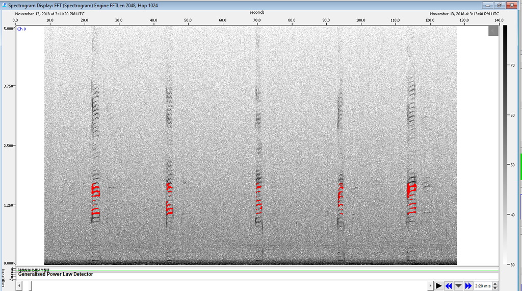